# Prediction Challenge

# To Do List

- LR Model
- Model Assessment
  - Step wise
  - Cutoff Selection
  - Compare Step vs General Model

# Objective

A supermarket is offering a new line of organic products.The supermarket’s management wants to determine which customers are likely to purchase these products.

The supermarket has a customer loyalty program. As an initial buyer incentive plan, the supermarket provided coupons for the organic products to all of the loyalty program participants and collected data that includes whether these customers purchased any of the organic products.

# Data Preprocessing

## Data Extraction

```r
rm(list=ls())
setwd("/Users/jpferrer95/Google Drive/Offline/Spring 2018/BIS 348/Data")
```

```
The working directory was changed to /Users/jpferrer95/Google Drive/Offline/Spring 2018/BIS 348/Data inside a notebook chunk. The working directory will be reset when the chunk is finished running. Use the knitr root.dir option in the setup chunk to change the the working directory for notebook chun…
```

```r
rdata = read.csv("organics.csv")
rdata = rdata[complete.cases(rdata),]
```

In order to focus just on the data we have, and without making any wild assumptions, we have decided to eliminate all entries with missing (NA or Null) values. By doing so we avoid pitfalls in our analysis.After eliminating the empty cells, we can notice the number of entries decreased from 22223 observations to 18904 observations.

## Data Cleaning / Dummies

This part of the process is important because we are trying to decide which categorical variables to be taken into account in our predictive model. We gotta create dummy variables for the following variables: Clusters, genders, regions, tv regions and promo class

```r
options(scipen=999)
# Cluster Dummies
rdata$isClusterA = ifelse(rdata$DemClusterGroup == 'A', 1, 0)
rdata$isClusterB = ifelse(rdata$DemClusterGroup == 'B', 1, 0)
rdata$isClusterC = ifelse(rdata$DemClusterGroup == 'C', 1, 0)
rdata$isClusterD = ifelse(rdata$DemClusterGroup == 'D', 1, 0)
rdata$isClusterE = ifelse(rdata$DemClusterGroup == 'E', 1, 0)
rdata$isClusterF = ifelse(rdata$DemClusterGroup == 'F', 1, 0)
# Gender Dummies
rdata$isMale= ifelse(rdata$DemGender == 'M', 1, 0)
rdata$isFemale = ifelse(rdata$DemGender == 'F', 1, 0)
# Region Dummies
rdata$isMidland = ifelse(rdata$DemReg == 'Midlands', 1, 0)
rdata$isNorth = ifelse(rdata$DemReg == 'North', 1, 0)
rdata$isScottish = ifelse(rdata$DemReg == 'Scottish', 1, 0)
rdata$isSouthEast = ifelse(rdata$DemReg == 'South East', 1, 0)
# TV Region Dummmies
rdata$isBorder = ifelse(rdata$DemTVReg == 'Border', 1, 0)
rdata$isCScotland = ifelse(rdata$DemTVReg == 'C Scotland', 1, 0)
rdata$isEast = ifelse(rdata$DemTVReg == 'East', 1, 0)
rdata$isLondon = ifelse(rdata$DemTVReg == 'London', 1, 0)
rdata$isMidlands = ifelse(rdata$DemTVReg == 'Midlands', 1, 0)
rdata$isNEast = ifelse(rdata$DemTVReg == 'N East', 1, 0)
rdata$isNScot = ifelse(rdata$DemTVReg == 'N Scot', 1, 0)
rdata$isNWest = ifelse(rdata$DemTVReg == 'N West', 1, 0)
rdata$isSSEast = ifelse(rdata$DemTVReg == 'S & S East', 1, 0)
rdata$isSWest= ifelse(rdata$DemTVReg == 'S West', 1, 0)
rdata$isUlster = ifelse(rdata$DemTVReg == 'Ulster', 1, 0)
rdata$isWalesWest = ifelse(rdata$DemTVReg == 'Wales & West', 1, 0)
# Promotion Class Dummies
rdata$isGold = ifelse(rdata$PromClass == 'Gold', 1, 0)
rdata$isPlatinum = ifelse(rdata$PromClass == 'Platinum', 1, 0)
rdata$isSilver = ifelse(rdata$PromClass == 'Silver', 1, 0)
```

The *base case*: U Cluster, Unknown gender, South West region, Yorkshire TV region, Tin promotion class

## Data Partitioning

```r
cdata = rdata[,-c(1,5,6,7,8,9,13)]
set.seed(123)
ti = sample(nrow(cdata), floor(nrow(cdata)*0.6))
train.df = cdata[ti,]
valid.df = cdata[-ti,]
```

##### Logistic Regression Model

# Logistic Regression Model

## Setting Up Model

```r
install.packages("forecast")
```

```
Error in install.packages : Updating loaded packages
```

```r
install.packages("caret")
```

```
Error in install.packages : Updating loaded packages
```

```r
library(forecast)
library(caret)
logReg = glm(TargetBuy~.,data = train.df, family = 'binomial')
logReg.pred = predict(logReg, newdata = valid.df, type = 'response')
```

```
prediction from a rank-deficient fit may be misleading
```

```r
pred = ifelse(logReg.pred > 0.5, 1, 0)
pred.df = data.frame(Actual = valid.df$TargetBuy, Prediction = pred,
                     Probability = logReg.pred )
#pred.df[order(-logReg.pred),]
confusionMatrix(pred, valid.df$TargetBuy)
```

```
Confusion Matrix and Statistics

          Reference
Prediction    0    1
         0 5409 1073
         1  323  757

               Accuracy : 0.8153928
                 95% CI : (0.8064611, 0.8240806)
    No Information Rate : 0.7580005
    P-Value [Acc > NIR] : < 0.00000000000000022204

                  Kappa : 0.4152344
 Mcnemar's Test P-Value : < 0.00000000000000022204

            Sensitivity : 0.9436497
            Specificity : 0.4136612
         Pos Pred Value : 0.8344647
         Neg Pred Value : 0.7009259
             Prevalence : 0.7580005
         Detection Rate : 0.7152870
   Detection Prevalence : 0.8571806
      Balanced Accuracy : 0.6786554

       'Positive' Class : 0
```

## Model Assessment

```r
# Choose Cutoff #
accT = c()
for(cutoff in seq(0, 1, 0.01)){
    cm = confusionMatrix(ifelse(logReg.pred > cutoff, 1, 0), valid.df$TargetBuy)
    accT = c(accT, cm$overall[1])
}
```

```
Levels are not in the same order for reference and data. Refactoring data to match.Levels are not in the same order for reference and data. Refactoring data to match.
```

```r
plot(accT ~ seq(0, 1, 0.01), xlab = "Cutoff Value", ylab = "", type = "l", ylim = c(0,1))
lines(1-accT ~ seq(0,1,0.01), type = "l", lty = 2)
```

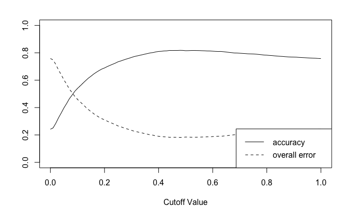

```r
legend("bottomright", c("accuracy", "overall error"), lty = c(1,2), merge = F)
```

*Reduce number of Predictors*

```r
# Reduced amount of variables taken into account
step.logReg = step(logReg, direction = 'both')
```

```
Start:  AIC=9689.97
TargetBuy ~ DemAffl + DemAge + DemCluster + PromSpend + PromTime +
    isClusterA + isClusterB + isClusterC + isClusterD + isClusterE +
    isClusterF + isMale + isFemale + isMidland + isNorth + isScottish +
    isSouthEast + isBorder + isCScotland + isEast + isLondon +
    isMidlands + isNEast + isNScot + isNWest + isSSEast + isSWest +
    isUlster + isWalesWest + isGold + isPlatinum + isSilver


Step:  AIC=9689.97
TargetBuy ~ DemAffl + DemAge + DemCluster + PromSpend + PromTime +
    isClusterA + isClusterB + isClusterC + isClusterD + isClusterE +
    isClusterF + isMale + isFemale + isMidland + isNorth + isScottish +
    isSouthEast + isBorder + isCScotland + isEast + isLondon +
    isMidlands + isNEast + isNScot + isNWest + isSSEast + isSWest +
    isUlster + isGold + isPlatinum + isSilver


Step:  AIC=9689.97
TargetBuy ~ DemAffl + DemAge + DemCluster + PromSpend + PromTime +
    isClusterA + isClusterB + isClusterC + isClusterD + isClusterE +
    isClusterF + isMale + isFemale + isMidland + isNorth + isScottish +
    isSouthEast + isBorder + isCScotland + isEast + isLondon +
    isMidlands + isNEast + isNScot + isNWest + isSSEast + isSWest +
    isGold + isPlatinum + isSilver


Step:  AIC=9689.97
TargetBuy ~ DemAffl + DemAge + DemCluster + PromSpend + PromTime +
    isClusterA + isClusterB + isClusterC + isClusterD + isClusterE +
    isClusterF + isMale + isFemale + isMidland + isNorth + isScottish +
    isSouthEast + isBorder + isCScotland + isEast + isLondon +
    isMidlands + isNEast + isNScot + isNWest + isSWest + isGold +
    isPlatinum + isSilver


Step:  AIC=9689.97
TargetBuy ~ DemAffl + DemAge + DemCluster + PromSpend + PromTime +
    isClusterA + isClusterB + isClusterC + isClusterD + isClusterE +
    isClusterF + isMale + isFemale + isMidland + isNorth + isScottish +
```

[output cut: 806 more lines]

```
+ isClusterF   1  9641.2464  9661.2464
+ PromTime     1  9641.2565  9661.2565
+ DemCluster   1  9641.2940  9661.2940
+ isLondon     1  9641.2962  9661.2962
+ isSSEast     1  9641.2962  9661.2962
+ PromSpend    1  9641.2992  9661.2992
+ isWalesWest  1  9641.3005  9661.3005
+ isNScot      1  9641.3013  9661.3013
- isSWest      1  9647.1560  9663.1560
- isSouthEast  1  9648.1736  9664.1736
- isMidland    1  9651.1406  9667.1406
- isMale       1  9734.2132  9750.2132
- isFemale     1 10205.9658 10221.9658
- DemAge       1 10376.0323 10392.0323
- DemAffl      1 10829.9371 10845.9371
```

```r
step.logReg.pred = predict(step.logReg, newdata = valid.df, type = 'response')
step.pred = ifelse(step.logReg.pred > 0.5, 1, 0)
step.pred.df = data.frame(Actual = valid.df$TargetBuy, Prediction = step.pred,
                          Probability = step.logReg.pred )
#pred.df[order(-logReg.pred),]
confusionMatrix(step.pred, valid.df$TargetBuy)
```

```
Confusion Matrix and Statistics

          Reference
Prediction    0    1
         0 5419 1063
         1  313  767

               Accuracy : 0.8180376
                 95% CI : (0.8091537, 0.8266756)
    No Information Rate : 0.7580005
    P-Value [Acc > NIR] : < 0.00000000000000022204

                  Kappa : 0.4236121
 Mcnemar's Test P-Value : < 0.00000000000000022204

            Sensitivity : 0.9453943
            Specificity : 0.4191257
         Pos Pred Value : 0.8360074
         Neg Pred Value : 0.7101852
             Prevalence : 0.7580005
         Detection Rate : 0.7166094
   Detection Prevalence : 0.8571806
      Balanced Accuracy : 0.6822600

       'Positive' Class : 0
```

# Neural Network Model

```r
# install.packages("caret",dependencies = TRUE)
library(neuralnet)
library(forecast)
library(caret)
# Normalize the data
nor = preProcess(cdata, method="range")
```

```
No variation for for: isUlster
```

```r
nn.data = predict(nor, cdata)
str(nn.data)
```

```
'data.frame':   18904 obs. of  33 variables:
 $ DemAffl    : num  0.294 0.118 0.147 0.294 0.324 ...
 $ DemAge     : num  0.951 0.508 0.852 0.77 0.82 ...
 $ DemCluster : num  0.2778 0.6296 0.4815 0.9259 0.0556 ...
 $ PromSpend  : num  0.0539967691 0.0202487673 0.0000000337 0 0 ...
 $ PromTime   : num  0.103 0.128 0.205 0.179 0.205 ...
 $ TargetBuy  : num  0 0 1 1 0 0 0 0 0 1 ...
 $ isClusterA : num  0 0 0 0 1 0 1 0 0 0 ...
 $ isClusterB : num  0 0 0 0 0 0 0 0 0 0 ...
 $ isClusterC : num  1 0 0 0 0 0 0 0 0 0 ...
 $ isClusterD : num  0 1 1 0 0 1 0 1 0 0 ...
 $ isClusterE : num  0 0 0 0 0 0 0 0 0 0 ...
 $ isClusterF : num  0 0 0 1 0 0 0 0 1 1 ...
 $ isMale     : num  0 0 0 1 0 0 0 1 1 0 ...
 $ isFemale   : num  0 0 1 0 1 0 1 0 0 1 ...
```

[output cut: 19 more lines]

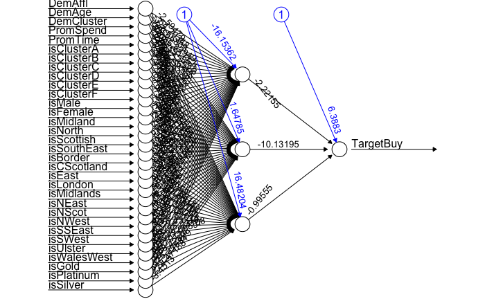

```r
train.df.nn = nn.data[ti,]
valid.df.nn = nn.data[-ti,]
# Getting the formula
n = names(train.df.nn)
f = as.formula(paste("TargetBuy~", paste(n[!n %in% "TargetBuy"], collapse = "+")))
nn.model = neuralnet(f, data = train.df.nn, linear.output = F,
                     hidden = 3,threshold = 0.1)
plot(nn.model)
```

```r
nn.model.pred = compute(nn.model,valid.df.nn[,-6] )
RMSE(ifelse(nn.model.pred$net.result > 0.5, 1, 0), valid.df.nn$TargetBuy)
```

```
[1] 0.4234591371
```

```r
accuracy(unlist(nn.model.pred),valid.df.nn$TargetBuy)
```

```
                   ME         RMSE         MAE  MPE MAPE
Test set -0.758000529 0.8706322582 0.758000529 -Inf  Inf
```

```r
result = ifelse(organic.nn.pred1$net.result > 0.5 ,1,0)
confusionMatrix(table(result, valid.df.nn$TargetBuy))
```

[output not shown]

```r
library(gains)
gain <- gains(valid.df.nn$TargetBuy, organic.nn.pred1$net.result, groups=10)
gain
```

```
Depth                            Cume   Cume Pct                     Mean
 of           Cume     Mean      Mean   of Total    Lift   Cume     Model
File     N      N      Resp      Resp      Resp    Index   Lift     Score
-------------------------------------------------------------------------
  10   756    756      0.78      0.78      32.1%     321    321      0.80
  20   756   1512      0.52      0.65      53.4%     213    267      0.52
  30   756   2268      0.29      0.53      65.4%     120    218      0.35
  40   756   3024      0.27      0.46      76.5%     111    191      0.25
  50   757   3781      0.18      0.41      83.9%      74    168      0.18
  60   756   4537      0.12      0.36      89.1%      51    148      0.13
  70   756   5293      0.11      0.32      93.6%      45    134      0.09
  80   756   6049      0.08      0.29      97.0%      34    121      0.06
  90   756   6805      0.05      0.27      99.2%      22    110      0.04
 100   757   7562      0.02      0.24     100.0%       8    100      0.02
```

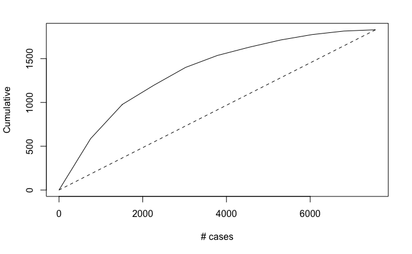

```r
plot(c(0, gain$cume.pct.of.total*sum(valid.df.nn$TargetBuy)) ~ c(0, gain$cume.obs),
     xlab="# cases", ylab="Cumulative", main="", type="l")
lines(c(0,sum(valid.df.nn$TargetBuy))~c(0, dim(valid.df.nn)[1]), lty=2)
```

```r
# Reduced amount of variables
selected.var = c(1,2,6,13,14,15,18,24,28)
set.seed(123)
sel.train.df.n = nn.data[ti,selected.var]
sel.valid.df.n = nn.data[-ti,selected.var]
nn.red.model = neuralnet(TargetBuy ~ DemAffl+DemAge+isMale+isFemale+isMidland+isSouthEast+isNEast+isSWest, data = sel.train.df.n, linear.output = F, hidden = 3,threshold = 0.1)
nn.red.pred = compute(nn.red.model, sel.valid.df.n[,-3])
result2 = ifelse(nn.red.pred$net.result > 0.5,1,0)
confusionMatrix(table(result2, sel.valid.df.n$TargetBuy))
```

```
Confusion Matrix and Statistics


result2    0    1
      0 5391  976
      1  341  854

               Accuracy : 0.8258397
                 95% CI : (0.8171007, 0.8343268)
    No Information Rate : 0.7580005
    P-Value [Acc > NIR] : < 0.00000000000000022204

                  Kappa : 0.4617066
 Mcnemar's Test P-Value : < 0.00000000000000022204

            Sensitivity : 0.9405094
            Specificity : 0.4666667
         Pos Pred Value : 0.8467096
         Neg Pred Value : 0.7146444
             Prevalence : 0.7580005
         Detection Rate : 0.7129066
   Detection Prevalence : 0.8419730
      Balanced Accuracy : 0.7035880

       'Positive' Class : 0
```

```r
# Choose Cutoff #
accT = c()
for(cutoff in seq(0, 1, 0.01)){
    cm = confusionMatrix(ifelse(nn.red.pred$net.result > cutoff, 1, 0), sel.valid.df.n$TargetBuy)
    accT = c(accT, cm$overall[1])
}
```

```
Levels are not in the same order for reference and data. Refactoring data to match.Levels are not in the same order for reference and data. Refactoring data to match.
```

```r
accT
```

```
    Accuracy     Accuracy     Accuracy     Accuracy     Accuracy     Accuracy
0.2419994710 0.2476857974 0.2893414441 0.3352287755 0.3819095477 0.4188045491
    Accuracy     Accuracy     Accuracy     Accuracy     Accuracy     Accuracy
0.4545093891 0.4841311822 0.5133562550 0.5366305210 0.5597725469 0.5805342502
    Accuracy     Accuracy     Accuracy     Accuracy     Accuracy     Accuracy
0.6044697170 0.6237767786 0.6388521555 0.6559111346 0.6693996297 0.6838138059
    Accuracy     Accuracy     Accuracy     Accuracy     Accuracy     Accuracy
0.6983602222 0.7074847924 0.7181962444 0.7319492198 0.7386934673 0.7441153134
    Accuracy     Accuracy     Accuracy     Accuracy     Accuracy     Accuracy
0.7565458873 0.7617032531 0.7656704576 0.7689764613 0.7769108701 0.7811425549
    Accuracy     Accuracy     Accuracy     Accuracy     Accuracy     Accuracy
0.7844485586 0.7874900820 0.7913250463 0.7976725734 0.8001851362 0.8029621793
    Accuracy     Accuracy     Accuracy     Accuracy     Accuracy     Accuracy
0.8042845808 0.8060037027 0.8087807458 0.8116900291 0.8153927532 0.8189632372
    Accuracy     Accuracy     Accuracy     Accuracy     Accuracy     Accuracy
0.8209468395 0.8225337212 0.8216080402 0.8229304417 0.8246495636 0.8257074848
    Accuracy     Accuracy     Accuracy     Accuracy     Accuracy     Accuracy
0.8253107643 0.8259719651 0.8258397249 0.8253107643 0.8257074848 0.8249140439
    Accuracy     Accuracy     Accuracy     Accuracy     Accuracy     Accuracy
0.8229304417 0.8234594023 0.8229304417 0.8224014811 0.8217402803 0.8212113198
    Accuracy     Accuracy     Accuracy     Accuracy     Accuracy     Accuracy
0.8185665168 0.8169796350 0.8176408358 0.8173763555 0.8176408358 0.8161861941
    Accuracy     Accuracy     Accuracy     Accuracy     Accuracy     Accuracy
0.8140703518 0.8115577889 0.8091774663 0.8083840254 0.8077228246 0.8058714626
    Accuracy     Accuracy     Accuracy     Accuracy     Accuracy     Accuracy
0.8036233801 0.8024332187 0.7989949749 0.7984660143 0.7979370537 0.7948955303
    Accuracy     Accuracy     Accuracy     Accuracy     Accuracy     Accuracy
0.7938376091 0.7921184872 0.7900026448 0.7885480032 0.7866966411 0.7844485586
    Accuracy     Accuracy     Accuracy     Accuracy     Accuracy     Accuracy
0.7835228775 0.7829939170 0.7819359958 0.7786299921 0.7775720709 0.7755884687
    Accuracy     Accuracy     Accuracy     Accuracy     Accuracy     Accuracy
0.7734726263 0.7717535044 0.7701666226 0.7687119810 0.7671250992 0.7663316583
    Accuracy     Accuracy     Accuracy     Accuracy     Accuracy
0.7648770167 0.7627611743 0.7614387728 0.7601163713 0.7580005290
```

```r
max(accT)
```

```
[1] 0.8259719651
```

```r
plot(accT ~ seq(0, 1, 0.01), xlab = "Cutoff Value", ylab = "", type = "l", ylim = c(0,1))
lines(1-accT ~ seq(0,1,0.01), type = "l", lty = 2)
```

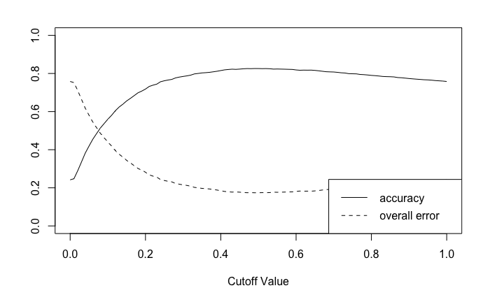

```r
legend("bottomright", c("accuracy", "overall error"), lty = c(1,2), merge = F)
```